# Homework2_BurakhanSel

Burakhan Sel

24 Ekim 2018

## Data Preparation

Before begining to analyze the data, we need to prepare it, create new columns or eliminate some of them according to our purposes. In this study, I explained the data preparation process with the comments near my codes.

```r
require(data.table)
require(anytime)
# Read Data
odd_details <- readRDS("C:/Users/Burakhan/Desktop/Dersler/IE 582/df9b1196-e3cf-4cc7-9159-f236fe738215_odd_details.rds")
matches <- readRDS("C:/Users/Burakhan/Desktop/Dersler/IE 582/df9b1196-e3cf-4cc7-9159-f236fe738215_matches.rds")


data<-data.table(merge(odd_details,matches,by="matchId")) #merge odd_details and matches datasets by matchIds


data$date.x<-anytime(data$date.x)#convert epoch to date
data$date.y<-anytime(data$date.y)#convert epoch to date
data<-data[order( as.POSIXct(data$date.x))] #order by date of the match


#splitting score column by ":"
data$score1 = as.numeric(lapply(strsplit(as.character(data$score), split=":"), "[", 1))
data$score2 = as.numeric(lapply(strsplit(as.character(data$score), split=":"), "[", 2))

# Adding a new column indicating whether the match is finished over or under 2.5
data[,is_it_over:=as.numeric((score1+score2)>=2.5)]

#Filtering oddtypes
data<-data[totalhandicap=="2.5" | totalhandicap=="0.5" | is.na(totalhandicap)]

#Adding a new column indicating whether the match is finished home,away or tie
data[,result:=ifelse(score1>score2,"Home",ifelse(score1<score2,"Away","Tie"))]

#combining oddtype and totalhandicap columns so that over/under 2.5 and over/under 0.5 will be different type of bets
data$ODDType <- paste(data$oddtype,data$totalhandicap,sep = " ")

#Considering only 5 of the bookmakers
bookmakers_data<-data[bookmaker=="bet-at-home" |bookmaker=="Betsson" |bookmaker=="10Bet" |bookmaker=="bet365" |bookmaker=="12BET"]

#Considering only the final bet from the data of the same matchId,ODDType,and bookmaker.
bookmakers_data<-unique(bookmakers_data,incomparables = FALSE, fromLast = TRUE, by=c("matchId","ODDType","bookmaker"))

 #Creating feature table
feature<-data.table(bookmakers_data[,.(matchId,bookmaker,is_it_over,result,ODDType,odd)])

# converting the feature table from long to wide range
feature<-reshape(feature, idvar = c("matchId","bookmaker","is_it_over","result") ,timevar = "ODDType", direction="wide")

#omitting the rows that has at least one NA because PCA doesn't work with the data that has NA
feature<-na.omit(feature)
```

## Task 1

### a) and Task 2

To apply pca to our data set, we need scaled feature variables. Luckily the princomp funciton does that when we set set the “cor” parameter to TRUE. After applying PCA, we can comment on Proportion of Variances that are covered by principle components by displaying with summary function.

```r
pca<-princomp(feature[,5:18],cor = TRUE,scores = TRUE) #scaling the data and applying PCA
summary(pca)
```

```
## Importance of components:
##                           Comp.1    Comp.2    Comp.3     Comp.4
## Standard deviation     2.5994834 2.0283586 1.5688477 0.53091609
## Proportion of Variance 0.4826653 0.2938742 0.1758059 0.02013371
## Cumulative Proportion  0.4826653 0.7765395 0.9523454 0.97247911
##                             Comp.5      Comp.6      Comp.7      Comp.8
## Standard deviation     0.339557671 0.292922811 0.249745033 0.201212611
## Proportion of Variance 0.008235672 0.006128841 0.004455184 0.002891894
## Cumulative Proportion  0.980714781 0.986843622 0.991298807 0.994190701
##                             Comp.9     Comp.10      Comp.11      Comp.12
## Standard deviation     0.184749183 0.122575901 0.1181244762 0.0944155673
## Proportion of Variance 0.002438019 0.001073204 0.0009966708 0.0006367357
## Cumulative Proportion  0.996628719 0.997701923 0.9986985938 0.9993353295
##                             Comp.13      Comp.14
## Standard deviation     0.0749327215 0.0607492773
## Proportion of Variance 0.0004010652 0.0002636053
## Cumulative Proportion  0.9997363947 1.0000000000
```

The first principle component(PC) covers nearly 48% of the variance, and the socend one covers the 29% of the total variance. With the third PC, we can resresent the 95% of the total variance cummulatively. We better see the behaviour of the PVE values on a plot.

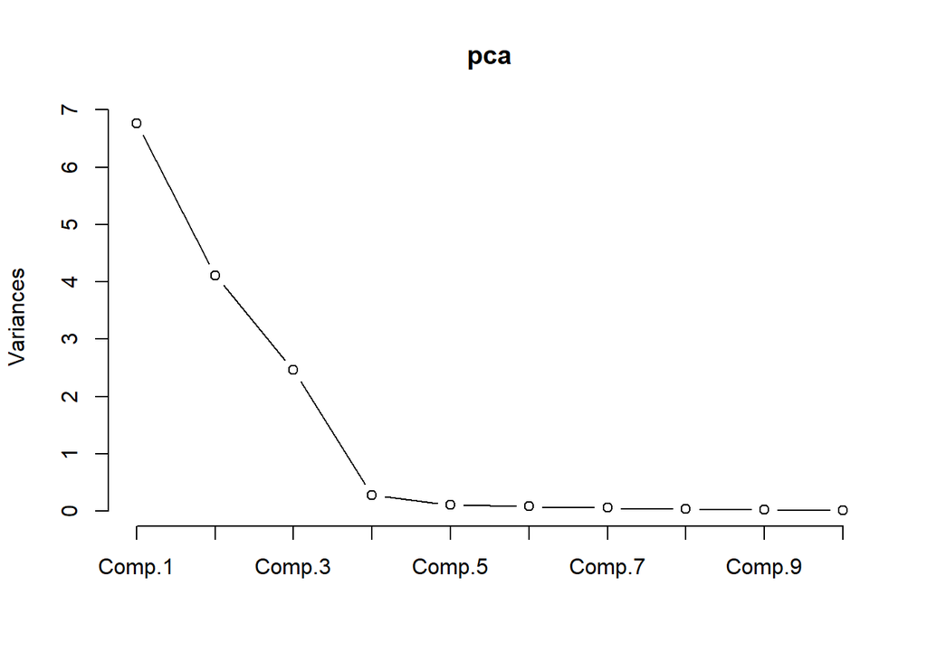

```r
plot(pca, type="l")
```

We can easily see the elbow at PC4. This means that after PC4, using additional PC’s may be unnecessary because the first 4 PC is representing the variance well.

As a double check, we can look at wherher our features are scaled to sd=1 or not.

```r
pca$sdev
```

```
##     Comp.1     Comp.2     Comp.3     Comp.4     Comp.5     Comp.6
## 2.59948341 2.02835861 1.56884765 0.53091609 0.33955767 0.29292281
##     Comp.7     Comp.8     Comp.9    Comp.10    Comp.11    Comp.12
## 0.24974503 0.20121261 0.18474918 0.12257590 0.11812448 0.09441557
##    Comp.13    Comp.14
## 0.07493272 0.06074928
```

As an additional information, “loadings” (eigenvectors) shows the directions of the PC’s. “scores” stores the data of representation of the data related to PC’s.

Let’s plot the PCA. I will use 2 different plotting functions for clear representation because the first one displays the arrows clearly whereas 2nd plot doens’t

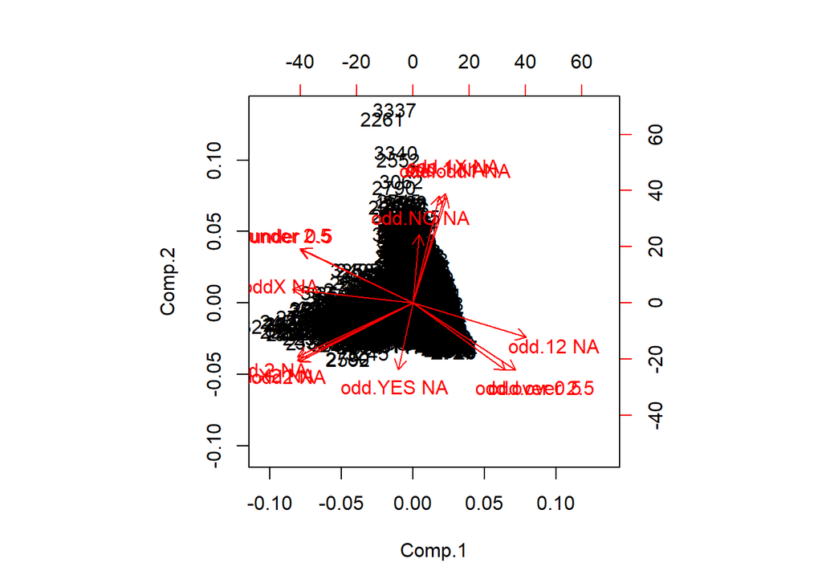

```r
require(ggbiplot)
biplot(pca)
```

In this plot, bottom and left axes are representing PCs, top and right axes are showing the values of eigenvectors which are red arrows. From the red arrows, we can see how much wieght principal components put on the features. Although, it is hard to read from the graph, we can interpret some of the eigenvectors. For example, while 1st PC put more wihgt to “odd.12 NA”" and “odd over 2.5” bet types, there is not much wight of “odd YES NA” on the 1st PC. Note that eigenvectors can also represent by reverse sign. Therefore, we can also say that “under 0.5” eigenvector in the top left has also weight on PC1. The interpretation of the 2nd PC is the same.

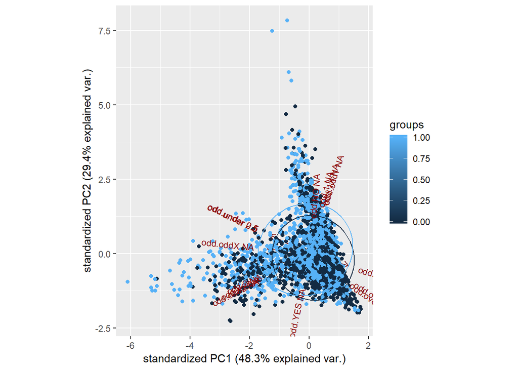

```r
ggbiplot(pca,ellipse = T, groups=feature$is_it_over,varname.size = 3)
```

From this graph, we can see the color coded version of scores.Since the arrows are not clearly seen, I commented on the arrows in the previous graph. In this graph, While blue dots represent the result of over 2.5, black dots represent the result of under 2.5. Although the discirimination of the blue and black dots is not clear, we can conclude from ellipses that, black dots are more or less gathered in the right bottom corner of the shape while blue dots spreaded in the directions of left bottom and rigt top. From that conclusion, as an example,we can say that if the odd of odd under 0.5 (top left) is high, the match will probably result over 2.5. On the other hand If “Odd 12 NA” (right bottom) is high the match will probably result under 2.5.

For clear representation I will decrase the number of features and consider only the easily differentiated ones. Then aplly a new PCA. This time the discrimination will be more clear.

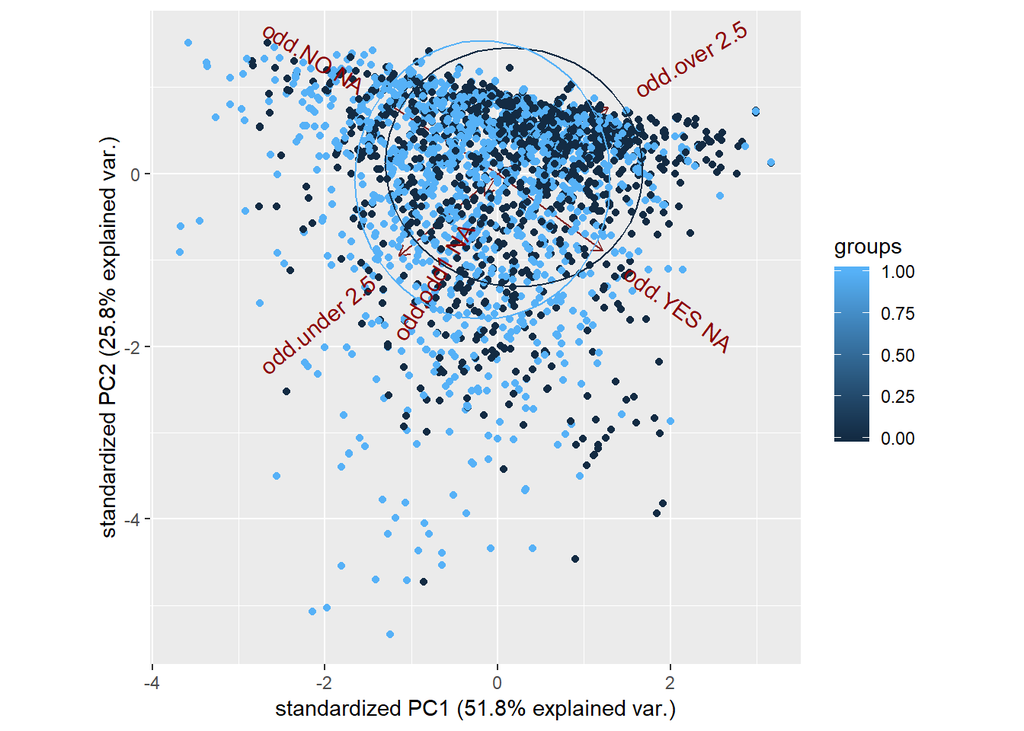

```r
new_feature<-data.table(feature[,.(matchId,bookmaker,is_it_over,result,`odd.over 2.5`,`odd.under 2.5`,`odd.YES NA`,`odd.NO NA`,`odd.odd1 NA`)])
reduced_pca<-princomp(new_feature[,5:9],cor = TRUE,scores = TRUE)
ggbiplot(reduced_pca,ellipse = T, groups = new_feature$is_it_over,varname.size = 4)
```

For the task 2, the same pca is colored with the group of Home, Away, and Tie results.

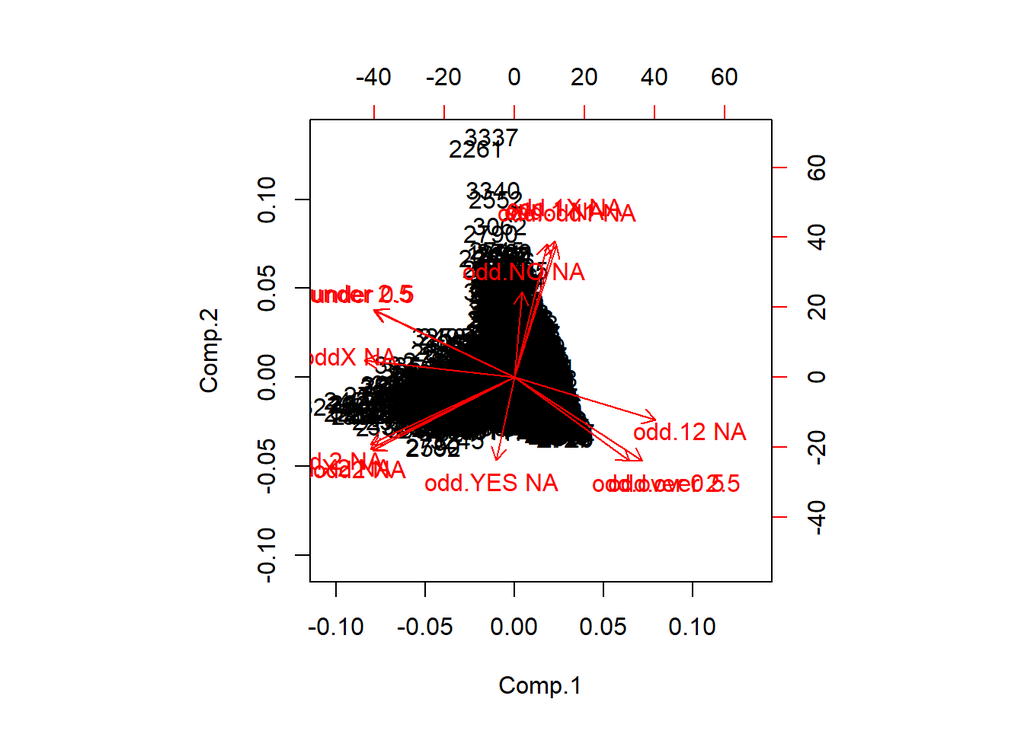

```r
biplot(pca)
```

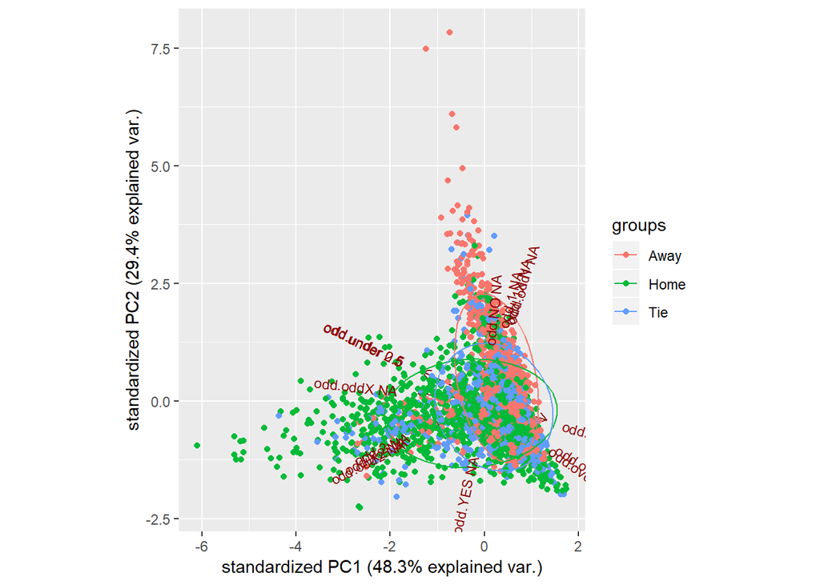

```r
ggbiplot(pca,ellipse = T, groups=feature$result)
```

## b)

In order to perform MDS, we first need to prepare our feature data and convert it to a distance matrix.

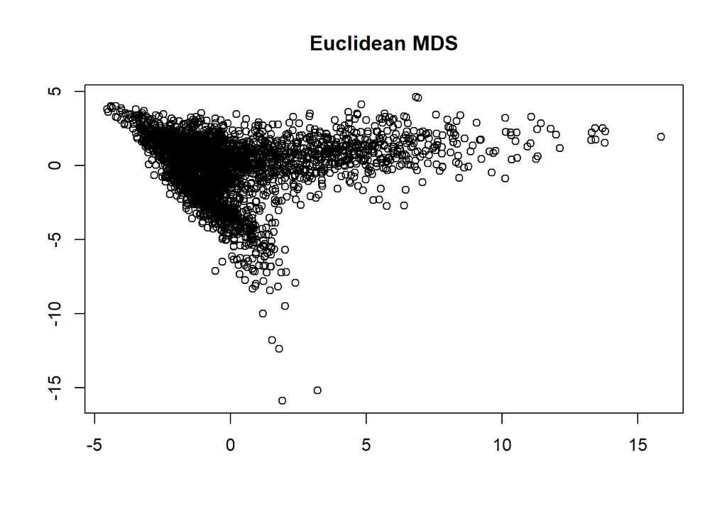

```r
feature_MDS<-feature[,c("result","matchId","is_it_over","bookmaker"):=NULL] #Deleting irrelevant columns
feature_MDS<-scale(feature_MDS)

 #converting it to a distance matrix using euclidean method
distanceMat<-dist(feature_MDS, method = "euclidean")
distanceMat[is.na(distanceMat)]=0 #removing na entries
mds=cmdscale(distanceMat) #applying MDS
plot(mds[,1],mds[,2],main='Euclidean MDS',xlab='', ylab='',col=1)
```

Let’s look at the MDS using manhattan method.

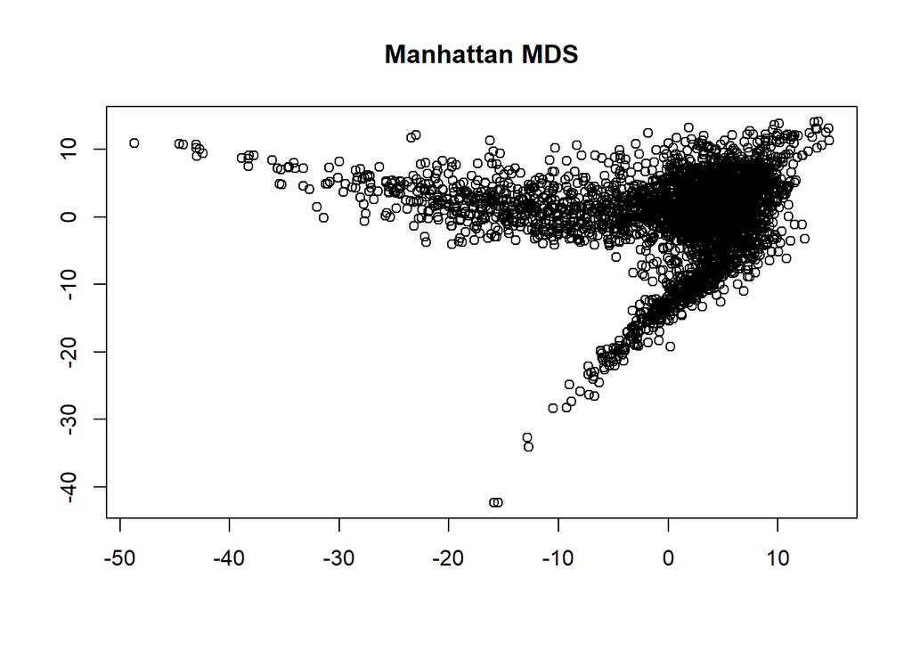

```r
 #converting it to a distance matrix using euclidean method
distanceMat<-dist(feature_MDS, method = "manhattan")
distanceMat[is.na(distanceMat)]=0 #removing na entries
mds=cmdscale(distanceMat) #applying MDS
plot(mds[,1],mds[,2],main='Manhattan MDS',xlab='', ylab='',col=1)
```

By comparing Manhattan MDS and euclidean MDS graphs, we can see that points in Euclidean MDS graph are closer to each other and gathered in the center. This means that, for this data set, manhattan distance method is better in terms of representing variance of the data.

## c)

We can see from both graph that shapes are almost same with the PCA graph. The reason for that is that the dimensions of MDS represents the data similar to Principle Components. Although shapes are similar,the direction and location of the shape in the graph is not same. This is because of - and + signs of PCA. (In PCA multiplying Eigenvector with -1 doesn’t affect the PVE)

## Task 3

```r
require(jpeg)
```

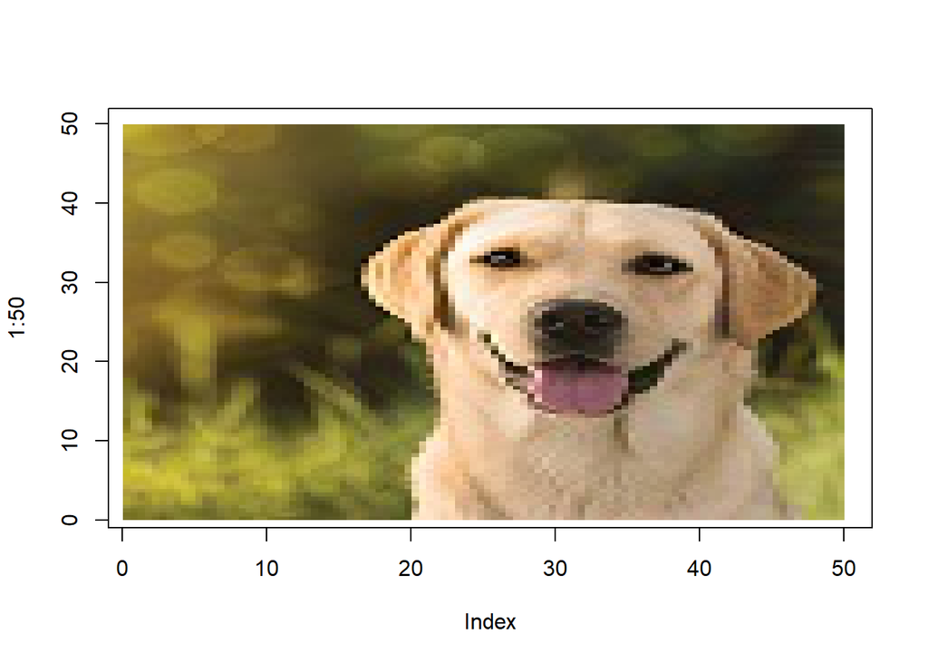

```r
dog_image<-readJPEG("Dog.jpg", native = F) #Read as a large array
plot(1:50, type='n')
rasterImage(dog_image,0,0,50,50,angle = 0,interpolate = F) #displaying the image
```

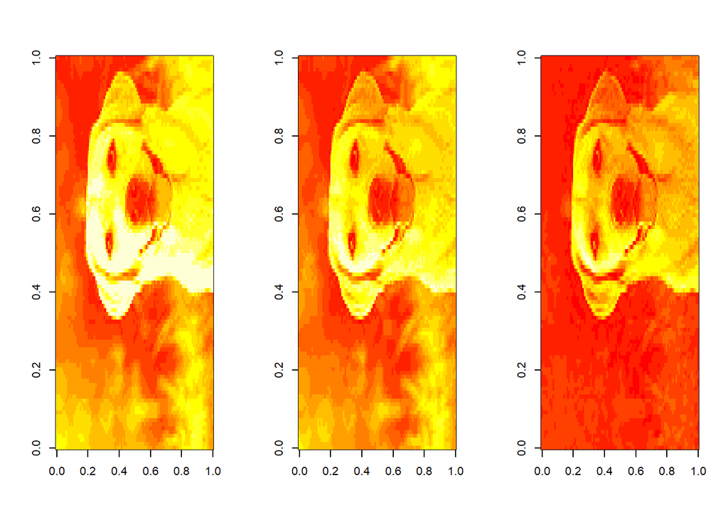

```r
#displaying each channel
par(mfrow=c(1,3))
image(dog_image[,,1])
image(dog_image[,,2])
image(dog_image[,,3])
```

```r
# Adding Noise to the image
Noisy_picture<-array(0,dim = c(nrow(dog_image),ncol(dog_image),3))
for(i in 1:3){
for(k in 1:nrow(dog_image)){
for(l in 1:ncol(dog_image)){
  random_number<-runif(1, min = 0, max = 0.1)
  if (dog_image[k,l,i]+random_number<=1){
Noisy_picture[k,l,i]<-dog_image[k,l,i]+random_number}
  else Noisy_picture[k,l,i]<-1
}}}
```

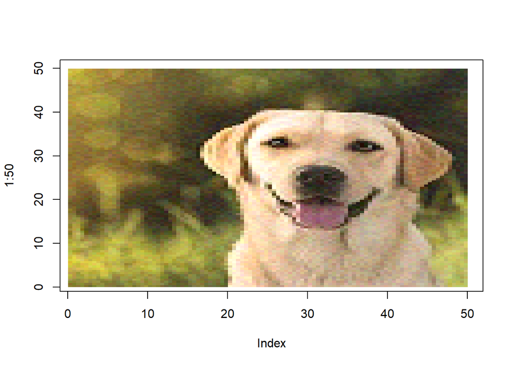

```r
par(mfrow=c(1,1))
plot(1:50, type='n')
rasterImage(Noisy_picture,0,0,50,50,angle = 0,interpolate = F)
```

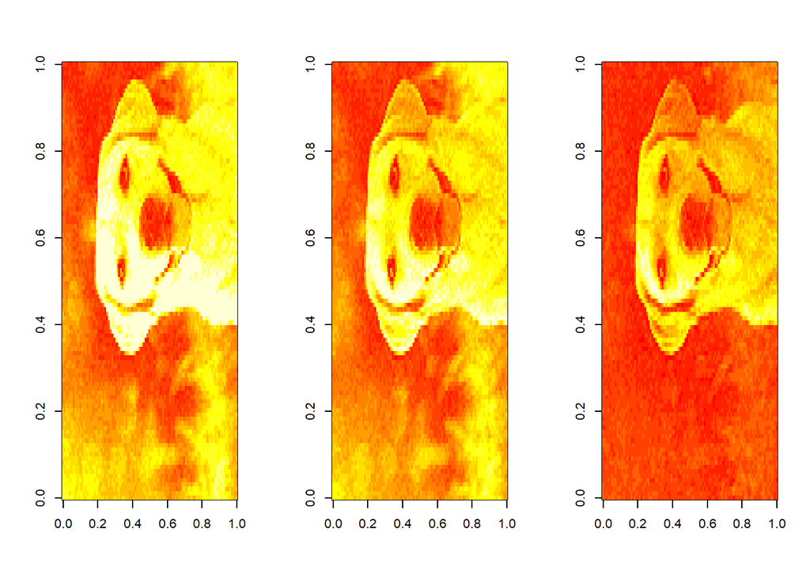

```r
#Displaying each Channel
par(mfrow=c(1,3))
image(Noisy_picture[,,1])
image(Noisy_picture[,,2])
image(Noisy_picture[,,3])
```

I converted the greyscale using an image editor. So read the greyscale image and display it:

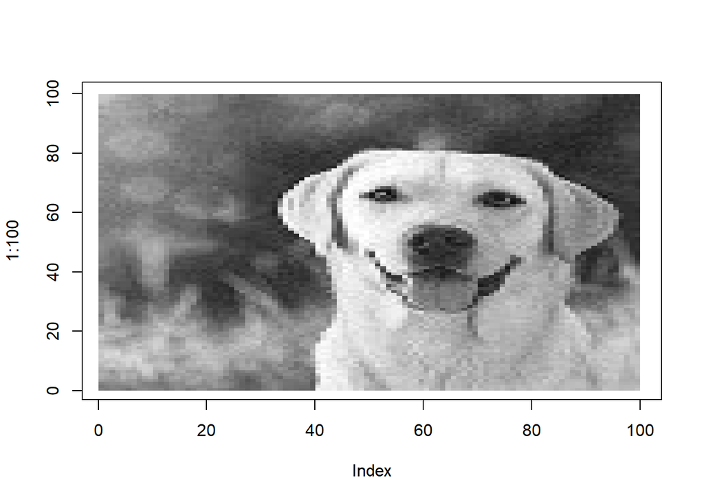

```r
Noisy_Dog_Image_Grey<-readJPEG("Noisy_Dog_Image_Grey.jpg",native = F)
plot(1:100, type='n')
rasterImage(Noisy_Dog_Image_Grey,0,0,100,100,angle = 0,interpolate = F)
```

Creating Patches with the help of for loops. Althoug my image is 100x100 pixel, it takes long hours to compute.

```r
Noisy_Dog_Image_Grey_Ch1<-Noisy_Dog_Image_Grey[,,1]

#creating patches
patch_data<-matrix(0,100*100,3*3)
patch_data<-data.table(patch_data)
r<-1
z<-1
for (i in 2:99) {
  for (k in 2:99) {
    for (l in i-1:i+1) {
      for(m in k-1:k+1){
        patch_data[r,z]<-Noisy_Dog_Image_Grey_Ch1[l,m]
        z<-z+1
        if(z==(10)){z=1}
      }}
    r<-r+1}}
```

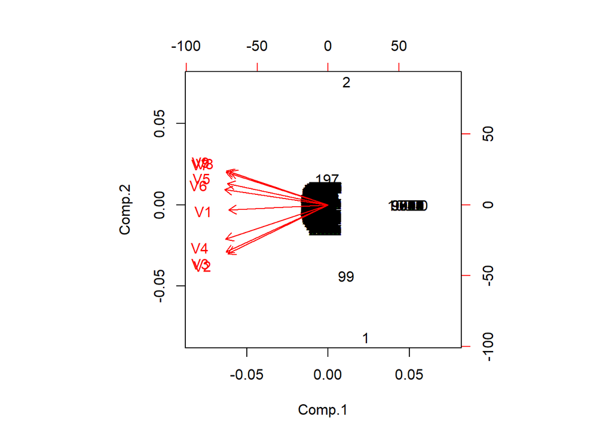

```r
pca<-princomp(patch_data,cor = T) #applying pca
biplot(pca)
```

The representation of a pacth is v1 v2 v3 v4 v5 v6 v7 v8 v9

When we look at the PCA graph we can see that every dimension has almost the same weights on PC1. In PC2, the edge sells such as v9 and v2 have high weight on PC1. This means that the these cells can represent the variance of the image better compare to the center cells. Probably, image of PC1 won’t show any detaild but image of PC2 can be more differentiable.

[figure not shown]

```r
range01 <- function(x){(x-min(x))/(max(x)-min(x))} #define a function to keep the values in [0,1] range
scaled_pca_score<-range01(pca$scores) #scale them with the defined function

#convert 1x(98*98) vector to a 98x98 matrix
PCA1_Image<-matrix(0,98,98)
i=1
for (k in 1:98){
  for (l in 1:98){
    PCA1_Image[k,l]<-scaled_pca_score[i,1]
    i<-i+1
  }}
plot(1:98, type='n')
rasterImage(PCA1_Image,0,0,98,98,angle = 0,interpolate = F)
```

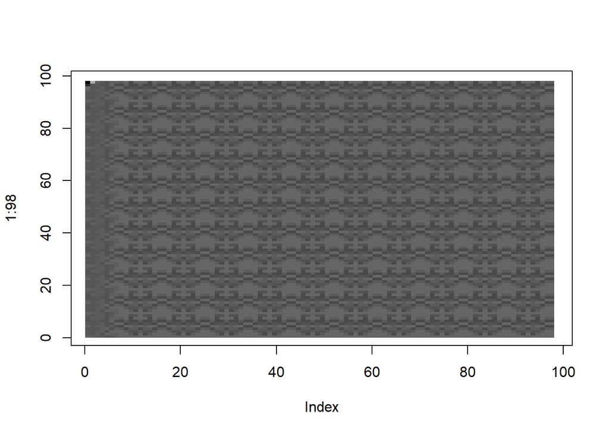

```r
PCA2_Image<-matrix(0,98,98)
i=1
for (k in 1:98){
  for (l in 1:98){
    PCA2_Image[k,l]<-scaled_pca_score[i,2]
    i<-i+1
  }}
plot(1:98, type='n')
rasterImage(PCA2_Image,0,0,98,98,angle = 0,interpolate = F) #image of PC2
```

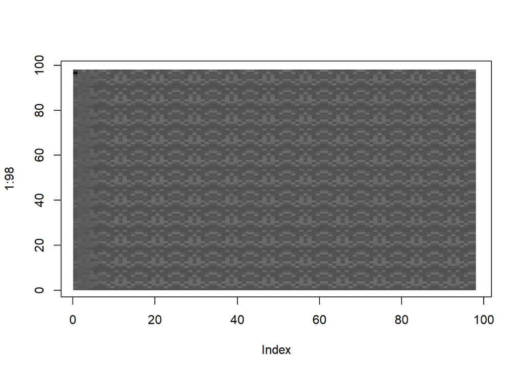

```r
PCA3_Image<-matrix(0,98,98)
i=1
for (k in 1:98){
  for (l in 1:98){
    PCA3_Image[k,l]<-scaled_pca_score[i,3]
    i<-i+1
  }}
plot(1:98, type='n')
rasterImage(PCA3_Image,0,0,98,98,angle = 0,interpolate = F) #image of PC2
```